# Actividad 3

Proyecto Transversal en R (I): Análisis de bioestadística aplicada a la expresión génica en Los Simpson

Grupo 22: Laura Córdova, Xiomira Fiallos, Lizbeth Navarrete, Soledad Ortega, Mirkka Puente, Melanie Polo

2026-01-22

```r
#Install libraries
#install.packages(c("factoextra", "nortest", "gtsummary","pheatmap")
#Libraries
library(ggplot2)
library(dplyr)
library(nortest)
library(stats)
library(car)
library(gtsummary)
library(tidyverse)
library(factoextra)
library(gridExtra)
library(pheatmap)
library(pROC)
file <- ("./Base de datos Los Simpson completa.csv")
df <- read.csv(file, stringsAsFactors = FALSE)
```

# 1 Limpieza de datos

```r
genes_interes <-names(df)[
  match("ADCY3", names(df)) :
  match("UHMK1", names(df))
]
genes_interes
```

```
##  [1] "ADCY3"    "AGRP"     "ANKRD27"  "ANO4"     "BDNF"     "CADM1"
##  [7] "CADM2"    "CALCR"    "CNR1"     "CREBRF"   "DPP9"     "FTO"
## [13] "GIPR"     "GPR151"   "GPR75"    "KIAA0586" "KIAA1109" "KSR2"
## [19] "LEP"      "LEPR"     "MC4R"     "MRAP2"    "NRP1"     "NRP2"
## [25] "NTRK2"    "PCSK1"    "PDE3B"    "PHIP"     "POMC"     "PPARG"
## [31] "ROBO1"    "SH2B1"    "SIM1"     "SPARC"    "TMEM18"   "UBR2"
## [37] "UHMK1"
```

```r
NA_gen<-sapply(df[, genes_interes], function(x) sum(is.na(x)))
NA_gen
```

```
##    ADCY3     AGRP  ANKRD27     ANO4     BDNF    CADM1    CADM2    CALCR
##        0        0        0        0        0        0        0        0
##     CNR1   CREBRF     DPP9      FTO     GIPR   GPR151    GPR75 KIAA0586
##        0        0        0        0        0        0        0        0
## KIAA1109     KSR2      LEP     LEPR     MC4R    MRAP2     NRP1     NRP2
##        0        0        0        0        0        0        0        0
##    NTRK2    PCSK1    PDE3B     PHIP     POMC    PPARG    ROBO1    SH2B1
##        0        0        0        0        0        0        0        0
##     SIM1    SPARC   TMEM18     UBR2    UHMK1
##        0        0        0        0        0
```

# 2 Test de Normalidad

```r
prueba_shapiro<- lapply(genes_interes, function(g) {

  x <- as.numeric(df[[g]])

  if (length(na.omit(x)) < 3 || sd(x, na.rm = TRUE) == 0) {
    return(data.frame(
      gene = g,
      W = NA,
      p_value = NA
    ))
  }

  test <- shapiro.test(x)

  data.frame(
    gene = g,
    W = test$statistic,
    p_value = test$p.value
  )
})

shapiro_table <- bind_rows(prueba_shapiro) %>%
  mutate(
    normalidad = ifelse(p_value >= 0.05,
                        "Normalidad",
                        "No normalidad")
  ) %>%
  arrange(p_value)
shapiro_table
```

```
##            gene         W      p_value    normalidad
## W...1     MRAP2 0.5813020 1.040271e-11 No normalidad
## W...2      BDNF 0.6088805 2.809579e-11 No normalidad
## W...3     CADM2 0.6377578 8.383200e-11 No normalidad
## W...4      ANO4 0.6928361 8.036672e-10 No normalidad
## W...5    CREBRF 0.6939832 8.447452e-10 No normalidad
## W...6      AGRP 0.7037216 1.296286e-09 No normalidad
## W...7     PDE3B 0.7046585 1.351462e-09 No normalidad
## W...8     ROBO1 0.7096021 1.686373e-09 No normalidad
## W...9       LEP 0.7145035 2.105453e-09 No normalidad
## W...10     SIM1 0.7450554 8.908516e-09 No normalidad
## W...11    NTRK2 0.7475458 1.006829e-08 No normalidad
## W...12    ADCY3 0.7494210 1.104575e-08 No normalidad
## W...13     UBR2 0.7556777 1.509604e-08 No normalidad
## W...14    PPARG 0.7714760 3.400075e-08 No normalidad
## W...15     POMC 0.7726812 3.622517e-08 No normalidad
## W...16  ANKRD27 0.7835263 6.469073e-08 No normalidad
## W...17     NRP2 0.7854548 7.185121e-08 No normalidad
## W...18    GPR75 0.7889142 8.686794e-08 No normalidad
## W...19     LEPR 0.7894208 8.933047e-08 No normalidad
## W...20     PHIP 0.7947748 1.203390e-07 No normalidad
## W...21     CNR1 0.8075122 2.493177e-07 No normalidad
## W...22     GIPR 0.8075788 2.502880e-07 No normalidad
## W...23    UHMK1 0.8086886 2.670551e-07 No normalidad
## W...24    CALCR 0.8283053 8.735421e-07 No normalidad
## W...25     KSR2 0.8312640 1.051617e-06 No normalidad
## W...26   TMEM18 0.8326419 1.147261e-06 No normalidad
## W...27    PCSK1 0.8435310 2.316967e-06 No normalidad
## W...28     NRP1 0.8451931 2.585638e-06 No normalidad
## W...29    CADM1 0.8481081 3.139317e-06 No normalidad
## W...30    SH2B1 0.8503462 3.648850e-06 No normalidad
## W...31     DPP9 0.8537016 4.582585e-06 No normalidad
## W...32 KIAA0586 0.8539065 4.647230e-06 No normalidad
## W...33      FTO 0.8609023 7.547348e-06 No normalidad
## W...34    SPARC 0.8782673 2.670831e-05 No normalidad
## W...35     MC4R 0.8851034 4.507145e-05 No normalidad
## W...36 KIAA1109 0.8919708 7.747962e-05 No normalidad
## W...37   GPR151 0.9033777 1.980377e-04 No normalidad
```

# 3 Análisis de Componentes Principales

```r
# ------------------------------------------------------------------
# Preparación de datos para PCA
# ------------------------------------------------------------------

genes_pca <- df[, genes_interes]

# Verificar que no haya NA
sum(is.na(genes_pca))
```

```
## [1] 0
```

```r
# Centrar y escalar las variables antes de PCA
genes_pca_scaled <- scale(genes_pca, center = TRUE, scale = TRUE)

# ------------------------------------------------------------------
# Ejecutar el PCA
# ------------------------------------------------------------------

# Realizar PCA
pca_result <- prcomp(genes_pca_scaled, center = FALSE, scale. = FALSE)

# ------------------------------------------------------------------
# Extraer los scores de las primeras 6 componentes principales
# ------------------------------------------------------------------

# Obtener los scores
pca_scores <- as.data.frame(pca_result$x[, 1:6])

# Renombrar las columnas
colnames(pca_scores) <- paste0("PC", 1:6)

# Agregar los scores al dataframe original
df <- cbind(df, pca_scores)

# Verificar que se agregaron correctamente
head(df[, c("nombre", "PC1", "PC2", "PC3", "PC4", "PC5", "PC6")])
```

```
##                   nombre        PC1       PC2         PC3        PC4        PC5
## 1          Barney Gumble 11.7298671 -1.263904  0.15551977  0.3682416 -0.8462730
## 2          Homer Simpson  9.1068725 -0.916133 -0.39265602 -2.2475300 -0.8447265
## 3 Apu Nahasapeemapetilon -1.4026722 -2.551887 -0.31967626 -0.1935785 -0.7668300
## 4          Patty Bouvier  0.2184065  3.707377 -0.07607582  0.1641068 -1.6334369
## 5          Selma Bouvier  0.1585549  4.016965  0.89061331 -0.1583399  0.7453183
## 6        Abraham Simpson -0.3049546  2.714335 -4.46657876 -0.1114826  2.8842741
##           PC6
## 1  0.04572501
## 2 -1.22550192
## 3 -0.37963659
## 4 -0.74629975
## 5 -0.87572417
## 6  0.83353877
```

```r
# ------------------------------------------------------------------
# Crear tablas de resumen del PCA
# ------------------------------------------------------------------

# TABLA 1: Varianza explicada por cada componente (R²)
varianza_explicada <- data.frame(
  Componente = paste0("PC", 1:length(pca_result$sdev)),
  Desviacion_Estandar = pca_result$sdev,
  Varianza = pca_result$sdev^2,
  Proporcion_Varianza = (pca_result$sdev^2) / sum(pca_result$sdev^2),
  Varianza_Acumulada = cumsum((pca_result$sdev^2) / sum(pca_result$sdev^2))
) %>%
  mutate(
    R_cuadrado = Proporcion_Varianza * 100,
    R_cuadrado_acumulado = Varianza_Acumulada * 100
  )

# Mostrar solo las primeras 6 componentes
tabla_varianza <- varianza_explicada[1:6, c("Componente", "R_cuadrado", "R_cuadrado_acumulado")]
print(tabla_varianza)
```

```
##   Componente R_cuadrado R_cuadrado_acumulado
## 1        PC1  12.481784             12.48178
## 2        PC2   8.561679             21.04346
## 3        PC3   6.526222             27.56968
## 4        PC4   6.131558             33.70124
## 5        PC5   5.355732             39.05697
## 6        PC6   4.888280             43.94525
```

```r
# TABLA 2: Cargas de las variables en los componentes principales
cargas_pca <- as.data.frame(pca_result$rotation[, 1:6])
cargas_pca <- round(cargas_pca, 3)
cargas_pca <- cbind(Variable = rownames(cargas_pca), cargas_pca)
rownames(cargas_pca) <- NULL

# Mostrar primeras filas
head(cargas_pca, 10)
```

```
##    Variable    PC1    PC2    PC3    PC4    PC5    PC6
## 1     ADCY3  0.331 -0.086  0.095 -0.095  0.058 -0.067
## 2      AGRP  0.066  0.090  0.103  0.214 -0.221 -0.216
## 3   ANKRD27 -0.149 -0.172  0.012 -0.304  0.060  0.064
## 4      ANO4  0.364 -0.030  0.026  0.040 -0.103 -0.128
## 5      BDNF  0.004  0.184 -0.094  0.092  0.292 -0.236
## 6     CADM1 -0.085 -0.083 -0.061  0.219 -0.224  0.293
## 7     CADM2 -0.009  0.326  0.052  0.177  0.155  0.232
## 8     CALCR -0.004  0.051  0.079  0.220 -0.180  0.181
## 9      CNR1  0.090 -0.041 -0.118 -0.191 -0.148 -0.011
## 10   CREBRF  0.005 -0.104  0.329  0.068  0.149  0.114
```

## 3.1 Visualizaciones PCA

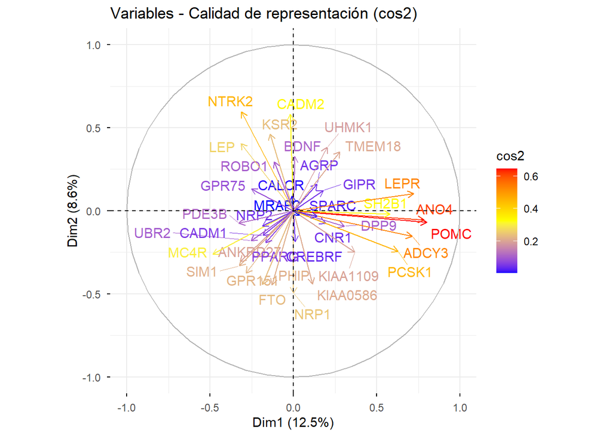

```r
# ------------------------------------------------------------------
# Visualizaciones
# ------------------------------------------------------------------
#Mapa de variables
fviz_pca_var(pca_result,
             col.var = "cos2",
             gradient.cols = c("blue", "yellow", "red"),
             repel = TRUE,
             title = "Variables - Calidad de representación (cos2)")
```

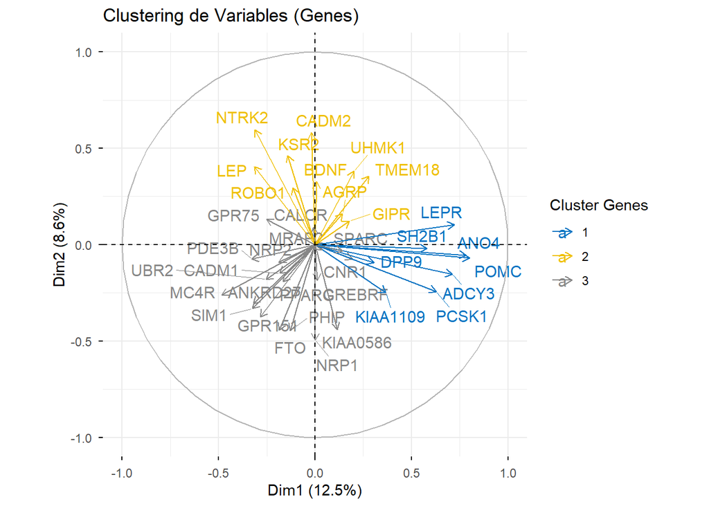

```r
#Contribucion de las variables
var_coords <- get_pca_var(pca_result)$coord
set.seed(123)
km_vars <- kmeans(var_coords, centers = 3)
grupo_vars <- as.factor(km_vars$cluster)
fviz_pca_var(pca_result,
             col.var = grupo_vars,
             palette = "jco",
             legend.title = "Cluster Genes",
             repel = TRUE,
             title = "Clustering de Variables (Genes)")
```

```r
# Contribución a la Dimensión 1 (PC1)
p1 <- fviz_contrib(pca_result, choice = "var", axes = 1, top = 10, title = "Contribución a PC1")
# Contribución a la Dimensión 2 (PC2)
p2 <- fviz_contrib(pca_result, choice = "var", axes = 2, top = 10, title = "Contribución a PC2")
```

**Interpretación PCA**: El gráfico de correlación de variables muestra cómo se relacionan los 37 genes con los dos primeros componentes principales (Dim1 y Dim2). Los genes con flechas más largas (color rojo/naranja según el cos2) son los que mejor están representados en el mapa y más aportan a la variabilidad de los datos. Los genes agrupados juntos indican una alta correlación positiva entre sí. Aquellos en cuadrantes opuestos presentarían una correlación negativa.

## 3.2 Gráficos de barras

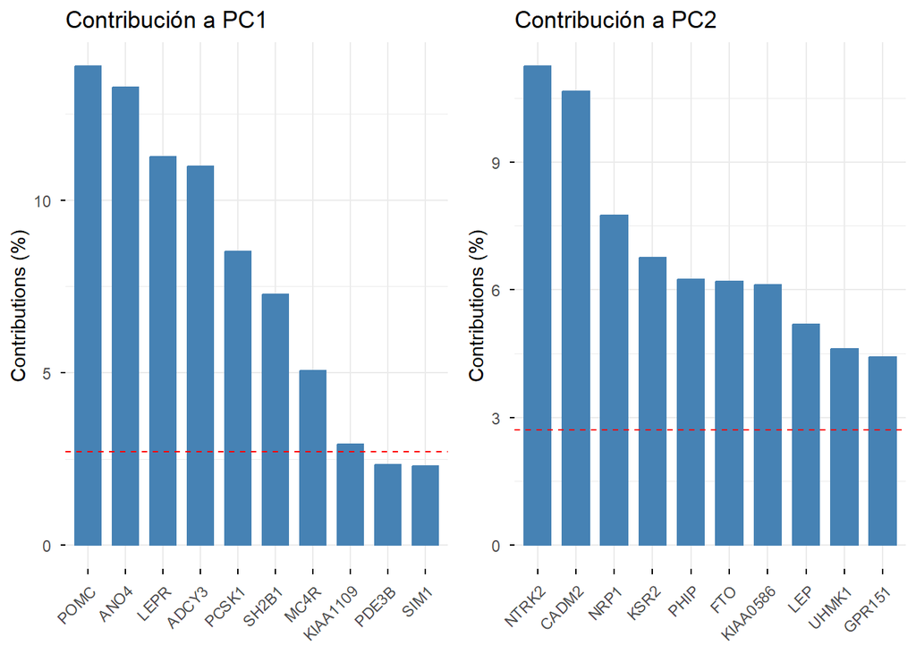

```r
# Mostrar ambos gráficos

grid.arrange(p1, p2, ncol = 2)
```

```r
# Criterio escogido: <25 Normal, 25-30 Sobrepeso, >30 Obesidad
df <- df %>%
  mutate(categoria_imc = case_when(
    imc_kg_m2 < 25 ~ "Normal",
    imc_kg_m2 >= 25 & imc_kg_m2 < 30 ~ "Sobrepeso",
    imc_kg_m2 >= 30 ~ "Obesidad",
    TRUE ~ "Desconocido"
  ))
```

**Interpretación**: Los gráficos de barras ilustran qué genes específicos tienen el mayor peso en la definición de cada componente: Contribución a PC1: Genes como POMC, ADCY3 y LEPR dominan este componente. Dado que estos genes regulan el apetito y el metabolismo energético, el PC1 puede interpretarse biológicamente como un eje altamente relacionado al metabolismo y apetito. Contribución a PC2: Genes como NTRK2 y CADM2 definen este componente, sugiriendo que el PC2 captura un patrón biológico distinto al de PC1.